# GAM y Splines del informe PISA 2006

Iker Aguirre Otaegui

11/8/2020

### Objetivos del trabajo.

modelizar la relación entre la puntuación media (OSS) del dataset “pisasci2006” y el resto de variables, utilizando modelos de splines y GAM.

## 1. Carga de librerías.

```r
library(here)
library(tidyverse)
library(janitor)
library(skimr)
library(magrittr)
```

```r
library(corrplot)
library(ggcorrplot)
library(PerformanceAnalytics)
library(leaps)
library(corrplot)
library(car)
library(boot)
library(gam)
```

## 2. Carga de la base de datos.

```r
pisa_raw <- read_csv("pisasci2006.csv")
```

## 3. Exploración preeliminar de datos raw.

```r
str(pisa_raw)
```

```
## tibble [65 × 11] (S3: spec_tbl_df/tbl_df/tbl/data.frame)
##  $ Country : chr [1:65] "Albania" "Argentina" "Australia" "Austria" ...
##  $ Overall : num [1:65] NA 391 527 511 382 510 390 434 534 438 ...
##  $ Issues  : num [1:65] NA 395 535 505 353 515 398 427 532 444 ...
##  $ Explain : num [1:65] NA 386 520 516 412 503 390 444 531 432 ...
##  $ Evidence: num [1:65] NA 385 531 505 344 516 378 417 542 440 ...
##  $ Interest: num [1:65] NA 567 465 507 612 503 592 523 469 591 ...
##  $ Support : num [1:65] NA 506 487 515 542 492 519 527 501 564 ...
##  $ Income  : num [1:65] 0.599 0.678 0.826 0.835 0.566 0.831 0.637 0.663 0.84 0.673 ...
##  $ Health  : num [1:65] 0.886 0.868 0.965 0.944 0.78 0.935 0.818 0.829 0.951 0.923 ...
##  $ Edu     : num [1:65] 0.716 0.786 0.978 0.824 NA 0.868 0.646 0.778 0.902 0.764 ...
##  $ HDI     : num [1:65] 0.724 0.773 0.92 0.866 NA 0.877 0.695 0.753 0.897 0.78 ...
##  - attr(*, "spec")=
##   .. cols(
##   ..   Country = col_character(),
##   ..   Overall = col_double(),
##   ..   Issues = col_double(),
##   ..   Explain = col_double(),
##   ..   Evidence = col_double(),
##   ..   Interest = col_double(),
##   ..   Support = col_double(),
##   ..   Income = col_double(),
##   ..   Health = col_double(),
##   ..   Edu = col_double(),
##   ..   HDI = col_double()
##   .. )
```

```r
head(pisa_raw)
```

```
## # A tibble: 6 x 11
##   Country Overall Issues Explain Evidence Interest Support Income Health    Edu
##   <chr>     <dbl>  <dbl>   <dbl>    <dbl>    <dbl>   <dbl>  <dbl>  <dbl>  <dbl>
## 1 Albania      NA     NA      NA       NA       NA      NA  0.599  0.886  0.716
## 2 Argent…     391    395     386      385      567     506  0.678  0.868  0.786
## 3 Austra…     527    535     520      531      465     487  0.826  0.965  0.978
## 4 Austria     511    505     516      505      507     515  0.835  0.944  0.824
## 5 Azerba…     382    353     412      344      612     542  0.566  0.78  NA
## 6 Belgium     510    515     503      516      503     492  0.831  0.935  0.868
## # … with 1 more variable: HDI <dbl>
```

```r
skim(pisa_raw)
```

Data summary

| Name | pisa_raw |
| --- | --- |
| Number of rows | 65 |
| Number of columns | 11 |
| _______________________ |  |
| Column type frequency: |  |
| character | 1 |
| numeric | 10 |
| ________________________ |  |
| Group variables | None |

**Variable type: character**

| skim_variable | n_missing | complete_rate | min | max | empty | n_unique | whitespace |
| --- | --- | --- | --- | --- | --- | --- | --- |
| Country | 0 | 1 | 4 | 24 | 0 | 65 | 0 |

**Variable type: numeric**

| skim_variable | n_missing | complete_rate | mean | sd | p0 | p25 | p50 | p75 | p100 | hist |
| --- | --- | --- | --- | --- | --- | --- | --- | --- | --- | --- |
| Overall | 8 | 0.88 | 473.14 | 54.58 | 322.00 | 428.00 | 489.00 | 513.00 | 563.00 | ▁▃▂▇▅ |
| Issues | 8 | 0.88 | 469.91 | 53.93 | 321.00 | 427.00 | 489.00 | 514.00 | 555.00 | ▁▃▂▇▆ |
| Explain | 8 | 0.88 | 475.02 | 54.02 | 334.00 | 432.00 | 490.00 | 517.00 | 566.00 | ▁▃▂▇▃ |
| Evidence | 8 | 0.88 | 469.81 | 61.74 | 288.00 | 423.00 | 489.00 | 515.00 | 567.00 | ▁▂▃▇▆ |
| Interest | 8 | 0.88 | 528.16 | 49.84 | 448.00 | 501.00 | 522.00 | 565.00 | 644.00 | ▆▇▅▃▂ |
| Support | 8 | 0.88 | 512.18 | 26.08 | 447.00 | 494.00 | 512.00 | 529.00 | 569.00 | ▂▅▇▆▂ |
| Income | 4 | 0.94 | 0.74 | 0.11 | 0.41 | 0.66 | 0.76 | 0.83 | 0.94 | ▁▃▇▇▆ |
| Health | 4 | 0.94 | 0.89 | 0.07 | 0.72 | 0.84 | 0.89 | 0.94 | 0.99 | ▂▂▇▆▇ |
| Edu | 6 | 0.91 | 0.80 | 0.11 | 0.54 | 0.72 | 0.81 | 0.88 | 0.99 | ▂▅▆▇▅ |
| HDI | 6 | 0.91 | 0.81 | 0.09 | 0.58 | 0.75 | 0.82 | 0.88 | 0.94 | ▁▃▇▇▇ |

## 4. Limpieza de los datos.

Habiendo visto la composición de los datos en el dataset, realizo varias modificaciones que considero adecuadas para posteriores análisis. Entre ellos:

1. Omisión de valores NA.
2. Rescribir el nombre variables a un formato adecuado.
3. Elimino variable “Country”.

```r
pisa <- na.omit(pisa_raw)
pisa %<>% clean_names()
pisa$country = NULL
pisa
```

```
## # A tibble: 52 x 10
##    overall issues explain evidence interest support income health   edu   hdi
##      <dbl>  <dbl>   <dbl>    <dbl>    <dbl>   <dbl>  <dbl>  <dbl> <dbl> <dbl>
##  1     391    395     386      385      567     506  0.678  0.868 0.786 0.773
##  2     527    535     520      531      465     487  0.826  0.965 0.978 0.92
##  3     511    505     516      505      507     515  0.835  0.944 0.824 0.866
##  4     510    515     503      516      503     492  0.831  0.935 0.868 0.877
##  5     390    398     390      378      592     519  0.637  0.818 0.646 0.695
##  6     434    427     444      417      523     527  0.663  0.829 0.778 0.753
##  7     534    532     531      542      469     501  0.84   0.951 0.902 0.897
##  8     438    444     432      440      591     564  0.673  0.923 0.764 0.78
##  9     542    528     549      542      536     529  0.853  0.966 0.763 0.857
## 10     388    402     379      383      644     546  0.616  0.829 0.624 0.683
## # … with 42 more rows
```

# 5. Análisis exploratorio de datos filtrados.

```r
head(pisa)
```

```
## # A tibble: 6 x 10
##   overall issues explain evidence interest support income health   edu   hdi
##     <dbl>  <dbl>   <dbl>    <dbl>    <dbl>   <dbl>  <dbl>  <dbl> <dbl> <dbl>
## 1     391    395     386      385      567     506  0.678  0.868 0.786 0.773
## 2     527    535     520      531      465     487  0.826  0.965 0.978 0.92
## 3     511    505     516      505      507     515  0.835  0.944 0.824 0.866
## 4     510    515     503      516      503     492  0.831  0.935 0.868 0.877
## 5     390    398     390      378      592     519  0.637  0.818 0.646 0.695
## 6     434    427     444      417      523     527  0.663  0.829 0.778 0.753
```

```r
skim(pisa)
```

Data summary

| Name | pisa |
| --- | --- |
| Number of rows | 52 |
| Number of columns | 10 |
| _______________________ |  |
| Column type frequency: |  |
| numeric | 10 |
| ________________________ |  |
| Group variables | None |

**Variable type: numeric**

| skim_variable | n_missing | complete_rate | mean | sd | p0 | p25 | p50 | p75 | p100 | hist |
| --- | --- | --- | --- | --- | --- | --- | --- | --- | --- | --- |
| overall | 0 | 1 | 471.15 | 53.99 | 322.00 | 427.00 | 488.00 | 511.25 | 563.00 | ▁▃▃▇▃ |
| issues | 0 | 1 | 469.08 | 52.78 | 321.00 | 427.00 | 484.50 | 511.00 | 555.00 | ▁▃▃▇▆ |
| explain | 0 | 1 | 472.52 | 54.07 | 334.00 | 430.50 | 487.00 | 516.25 | 566.00 | ▁▃▂▇▃ |
| evidence | 0 | 1 | 467.65 | 59.87 | 288.00 | 421.50 | 488.00 | 511.75 | 567.00 | ▁▂▃▇▅ |
| interest | 0 | 1 | 527.81 | 50.42 | 448.00 | 498.00 | 522.00 | 565.50 | 644.00 | ▆▇▅▃▂ |
| support | 0 | 1 | 510.88 | 26.37 | 447.00 | 491.75 | 511.50 | 529.00 | 569.00 | ▂▃▇▅▂ |
| income | 0 | 1 | 0.75 | 0.11 | 0.41 | 0.68 | 0.77 | 0.83 | 0.91 | ▁▁▆▅▇ |
| health | 0 | 1 | 0.89 | 0.06 | 0.74 | 0.84 | 0.91 | 0.94 | 0.99 | ▂▃▆▆▇ |
| edu | 0 | 1 | 0.81 | 0.11 | 0.54 | 0.76 | 0.83 | 0.90 | 0.99 | ▂▃▆▇▆ |
| hdi | 0 | 1 | 0.81 | 0.09 | 0.58 | 0.76 | 0.84 | 0.88 | 0.94 | ▁▃▆▆▇ |

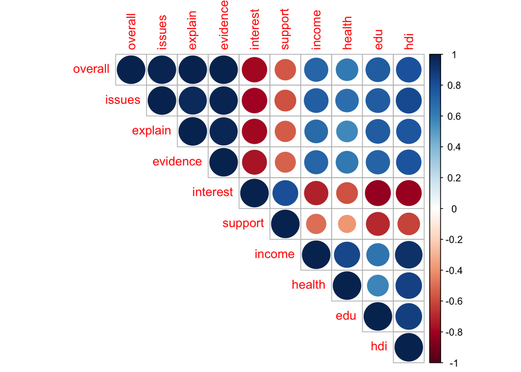

```r
corr_pisa <- cor(pisa)
corrplot(corr_pisa, type = "upper")
```

Se puede observar que las variables “issues”, “explain” y “evidence” no solo están altamente correlacionadas con la variable endógena “overall”, sino que también entre ellas. Las elimino para evitar problemas de multicolinealidad.

```r
pisa$issues <- NULL
pisa$explain <- NULL
pisa$evidence <- NULL
```

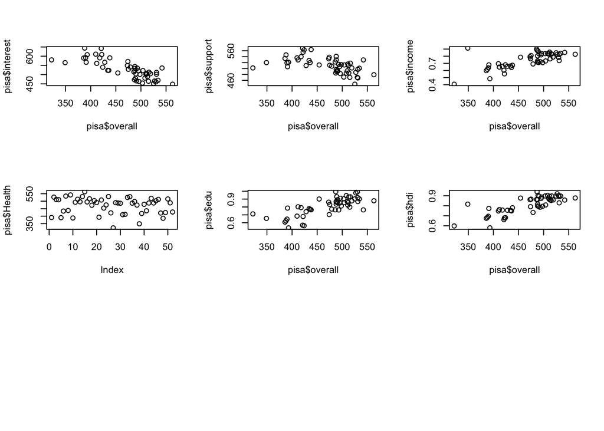

```r
par(mfrow=c(3,3))
plot(pisa$overall,pisa$interest)
plot(pisa$overall,pisa$support)
plot(pisa$overall,pisa$income)
plot(pisa$overall,pisa$Health)
plot(pisa$overall,pisa$edu)
plot(pisa$overall,pisa$hdi)
```

En esta representación gráfica se aprecia la posibilidad de que una o varias variables no sean las más adecuadas para realizar una regresión lineal. Por ello, estudio la linealidad de los predictores tras realizar una regresión simple.

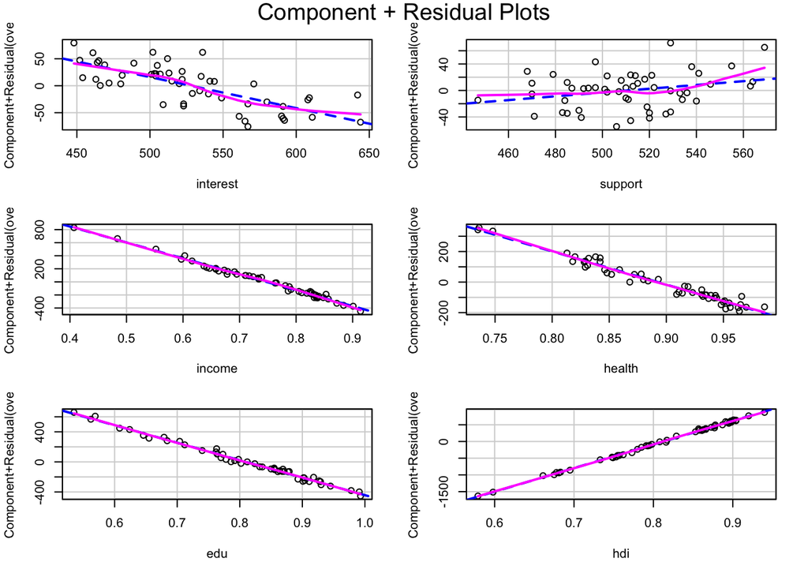

```r
library(car)
rpisa_lineal <- lm(overall ~  interest + support +income + health + edu + hdi, data = pisa)
crPlots(rpisa_lineal)
```

Una vez realidada la prueba de linealidad, se observa como una regresión lineal con las variables “interest” y “support”no sería lo ideal de cara a recoger toda la varianza de los datos. Por ello, lo adecuado sería recurrir a una regresión polinómica.

## 6. Cálculo del grado del polinomio

Determinamos el grado del polinomio óptimo para ambas variables, que será aquel que tenga menor error. Utilizamos hasta un exponente de 7.

```r
library(boot)

set.seed(814)
cv_errors_interest <- data.frame(degree=seq(1,7,1),
                        error= rep(NA, 7))
for (i in 1:7) {
    glm_interest <- glm(overall~poly(interest, i), data=pisa)
   cv_errors_interest$error[i] <- cv.glm(pisa, glm_interest, K=10)$delta[1]
}
cv_errors_interest
```

```
##   degree    error
## 1      1 1218.348
## 2      2 1245.159
## 3      3 1151.375
## 4      4 1140.566
## 5      5 1125.477
## 6      6 1096.750
## 7      7 1070.500
```

Como podemos observar, el error se va disminuyendo según vamos aumentando el nivel del polinomio. Puesto que queremos evitar overfitting, la intención es usar como máximo el grado 3 o 4. Vista su escasa disparidad de error, nos decantamos por un polinomio cúbico.

```r
set.seed(814)
cv_errors_support <- data.frame(degree=seq(1,7,1),
                        error= rep(NA, 7))
for (i in 1:7) {
    glm_support <- glm(overall~poly(support, i), data=pisa)
   cv_errors_support$error[i] <- cv.glm(pisa, glm_support, K=10)$delta[1]
}
cv_errors_support
```

```
##   degree     error
## 1      1  2237.126
## 2      2  2154.781
## 3      3  2129.620
## 4      4  2210.108
## 5      5  3691.610
## 6      6 10531.356
## 7      7  6464.423
```

## 7. Cálculo de los grados de libertad.

Utilizamos la función smooth.splines para calcular por cross-validation los grados de libertad para splines suaves cúbicas, que es el grado de polinomio que vamos a utilizar en ambas varibles.

```r
sspline_interest <- smooth.spline(x = pisa$interest,
                                 y = pisa$overall,
                                 cv = TRUE)
sspline_interest$df
```

```
## [1] 4.726395
```

```r
sspline_support <- smooth.spline(x = pisa$support,
                                 y = pisa$overall,
                                 cv = TRUE)
sspline_support$df
```

```
## [1] 2.000681
```

## 7. Modelo GAM.

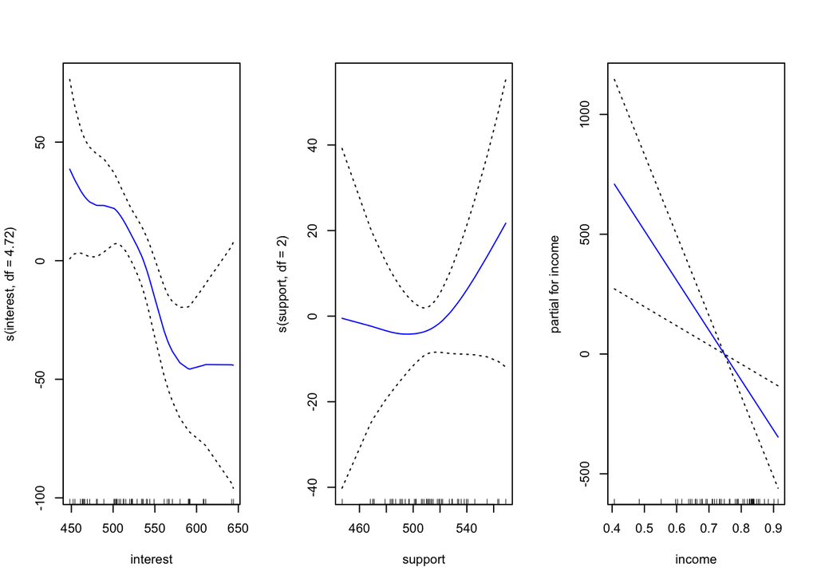

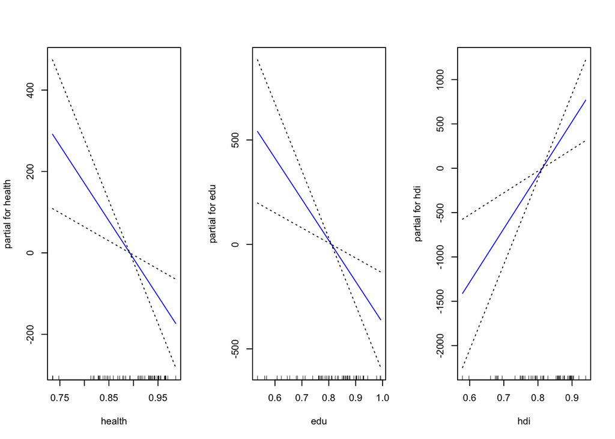

```r
library(gam)
gam <- gam(overall ~  s(interest,df=4.72) + s(support,df=2) +income +
              health + edu + hdi, data = pisa)
par(mfrow=c(1, 3))
plot(gam, se=TRUE, col='blue')
```

```r
summary(gam)
```

```
##
## Call: gam(formula = overall ~ s(interest, df = 4.72) + s(support, df = 2) +
##     income + health + edu + hdi, data = pisa)
## Deviance Residuals:
##     Min      1Q  Median      3Q     Max
## -50.370 -15.618   1.376  17.895  65.895
##
## (Dispersion Parameter for gaussian family taken to be 686.2015)
##
##     Null Deviance: 148644.8 on 51 degrees of freedom
## Residual Deviance: 27640.38 on 40.2803 degrees of freedom
## AIC: 499.3501
##
## Number of Local Scoring Iterations: NA
##
## Anova for Parametric Effects
##                           Df Sum Sq Mean Sq  F value   Pr(>F)
## s(interest, df = 4.72)  1.00  91193   91193 132.8960 2.48e-14 ***
## s(support, df = 2)      1.00   1530    1530   2.2299 0.143157
## income                  1.00   4283    4283   6.2410 0.016662 *
## health                  1.00    731     731   1.0652 0.308186
## edu                     1.00   3153    3153   4.5944 0.038168 *
## hdi                     1.00   7811    7811  11.3835 0.001649 **
## Residuals              40.28  27640     686
## ---
## Signif. codes:  0 '***' 0.001 '**' 0.01 '*' 0.05 '.' 0.1 ' ' 1
##
## Anova for Nonparametric Effects
##                        Npar Df Npar F   Pr(F)
## (Intercept)
## s(interest, df = 4.72)     3.7 2.2536 0.08442 .
## s(support, df = 2)         1.0 2.4647 0.12425
## income
## health
## edu
## hdi
## ---
## Signif. codes:  0 '***' 0.001 '**' 0.01 '*' 0.05 '.' 0.1 ' ' 1
```

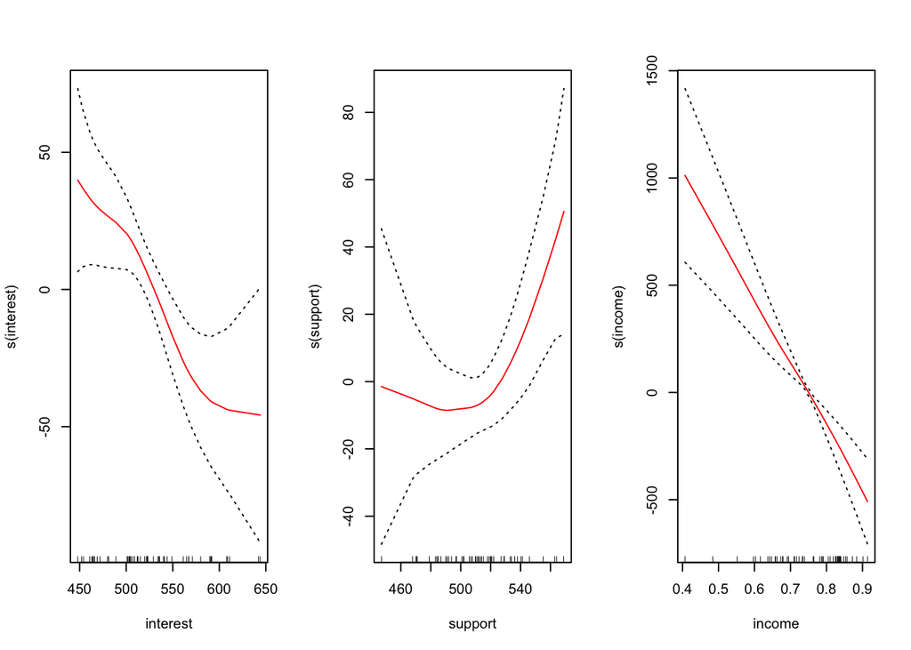

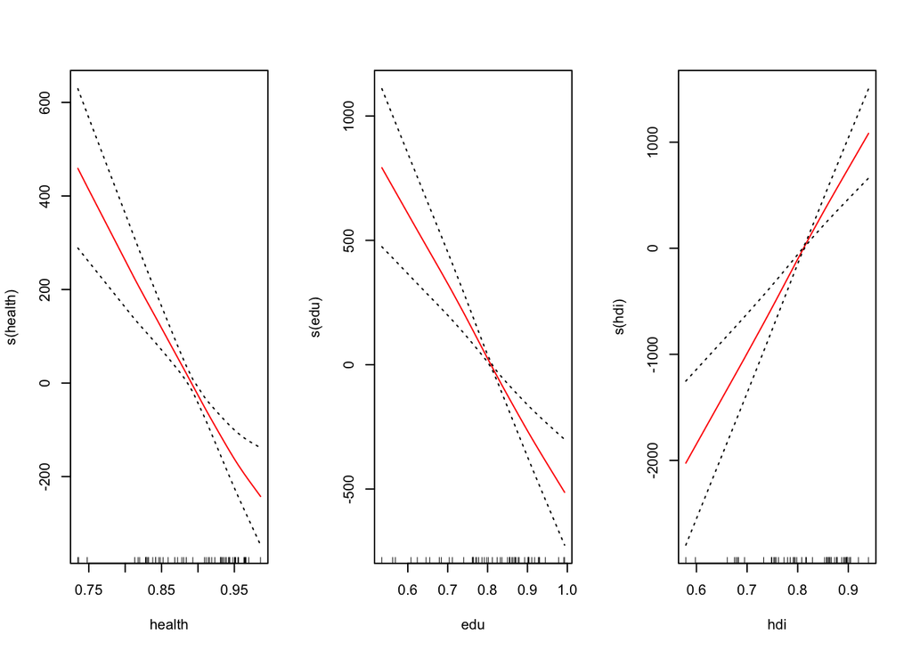

```r
library(gam)
gam2 <- gam(overall ~  s(interest) + s(support) + s(income) + s(health)
            + s(edu) + s(hdi), data = pisa)
par(mfrow=c(1, 3))
plot(gam2, se=TRUE, col='red')
```

```r
AIC(gam, gam2)
```

```
##      df      AIC
## gam   8 499.3501
## gam2  8 496.8235
```

En este caso nos quedamos con el segundo modelo.